# Part III: Eigenfaces and Simple Face Recognition [15 Points]

In this project, we will apply a simplified illustration of using PCA for face recognition. We will use a subset of data from the famous Yale Face dataset. First, given a set of images for each person, we generate the eigenface using these images. We will treat one picture from the same person as one data point for that person. Note that we will first vectorize each image, which was originally a matrix. Thus, the data matrix (for each person) is a matrix; each row is a vectorized picture. We will find weight vectors to combine the pictures to extract different eigenfaces that correspond to that person's pictures' first few principal components.

Prior to beginning our analysis, we first need to do load in both our libraries and our image data.

```python
from PIL import Image
import matplotlib.pyplot as plt
from skimage import data,color
from skimage.transform import rescale,resize
import numpy as np
```

Now that our libraries have been successfully loaded, we need to define a couple of utility functions to deal with converting our images to and from grayscale. We define these three functions below in order to covert between the two and to plot the results quickly.

```python
def im2gnp(image):
    return np.array(image.convert ('L'))

def gnp2im(image_np):
    return Image.fromarray(image_np.astype(np.uint8), mode='L')

def imshow_gray(im, ax=None):
    if ax is None:
        f = plt.figure()
        ax = plt.axes()
    ax.imshow(im,
              interpolation='nearest',
              cmap=plt.get_cmap('gray'))
```

Due to the native format of our image data as a gif, we will need to apply some manipulations using the Pillow library to get everything loaded and shaped correctly. We apply all of these operations in the code cells below. Also note our special treatment of the subjects 1 and 2 keeping their images separate.

```python
subject_1_train_image_paths = ['Yale_Faces_Images/subject01.glasses.gif','Yale_Faces_Images/subject01.happy.gif','Yale_Faces_Images/subject01.leftlight.gif','Yale_Faces_Images/subject01.noglasses.gif','Yale_Faces_Images/subject01.normal.gif','Yale_Faces_Images/subject01.rightlight.gif','Yale_Faces_Images/subject01.sad.gif','Yale_Faces_Images/subject01.sleepy.gif','Yale_Faces_Images/subject01.surprised.gif','Yale_Faces_Images/subject01.wink.gif']
subject_2_train_image_paths = ['Yale_Faces_Images/subject02.glasses.gif','Yale_Faces_Images/subject02.happy.gif','Yale_Faces_Images/subject02.leftlight.gif','Yale_Faces_Images/subject02.noglasses.gif','Yale_Faces_Images/subject02.normal.gif','Yale_Faces_Images/subject02.rightlight.gif','Yale_Faces_Images/subject02.sad.gif','Yale_Faces_Images/subject02.sleepy.gif','Yale_Faces_Images/subject02.wink.gif']

subject_1_test_image_paths = ['Yale_Faces_Images/subject01-test.gif']
subject_2_test_image_paths = ['Yale_Faces_Images/subject02-test.gif']

subject_1_images = []
subject_2_images = []

subject_1_test = []
subject_2_test = []
for a in subject_1_test_image_paths:
    im = Image.open(a,'r')
    subject_1_test.append(im2gnp(im))

for b in subject_2_test_image_paths:
    im = Image.open(b,'r')
    subject_2_test.append(im2gnp(im))

for i in subject_1_train_image_paths:
    im = Image.open(i,'r')
    subject_1_images.append(im2gnp(im))

for j in subject_2_train_image_paths:
    im = Image.open(j,'r')
    subject_2_images.append(im2gnp(im))


num_images,height_down,width_down = np.array(subject_1_images).shape

subject_1_array = np.reshape(np.array(subject_1_images),(10,77760))
subject_2_array = np.reshape(np.array(subject_2_images),(9,77760))

subject_1_test_array = np.reshape(np.array(subject_1_test),(1,77760))
subject_2_test_array = np.reshape(np.array(subject_2_test),(1,77760))
```

Now that our images have been correctly loaded for both subjects, we will begin the process of extracting the eigen faces. First, we apply centering to both subjects' image arrays. After this, we apply singular value decomposition via NumPy which equivalent to applying PCA. We then retrieve the top six principal components from both subjects resulting embeddings. In the cells below, we implement principal components analysis on the Yale faces dataset and return the top 6 "eigenfaces" for each of the two subjects with two images utilized as held out data.

```python
subject_1_centered = subject_1_array - np.expand_dims(np.average(subject_1_array,axis=1),axis=1)
subject_2_centered = subject_2_array - np.expand_dims(np.average(subject_2_array,axis=1),axis=1)

U_s1,Sigma_s1,VT_s1 = np.linalg.svd(np.cov(subject_1_centered,ddof=0))
U_s2,Sigma_s2,VT_s2 = np.linalg.svd(np.cov(subject_2_centered,ddof=0))
VT_s1_k = VT_s1[0:6,:]
VT_s2_k = VT_s2[0:6,:]
Sigma_s1_k = Sigma_s1[0:6]
Sigma_s2_k = Sigma_s2[0:6]
subject_1_pc = []
subject_2_pc = []
for i in range(0,6):
    subject_1_pc.append(np.reshape(VT_s1_k[i,:].T.dot(subject_1_centered) / np.sqrt(Sigma_s1_k[i]),(243,320)))
    subject_2_pc.append(np.reshape(VT_s2_k[i,:].T.dot(subject_2_centered) / np.sqrt(Sigma_s2_k[i]),(243,320)))
```

Now that we have retrieved embeddings for both subjects let's visualize the resulting eigenfaces for subject 1:

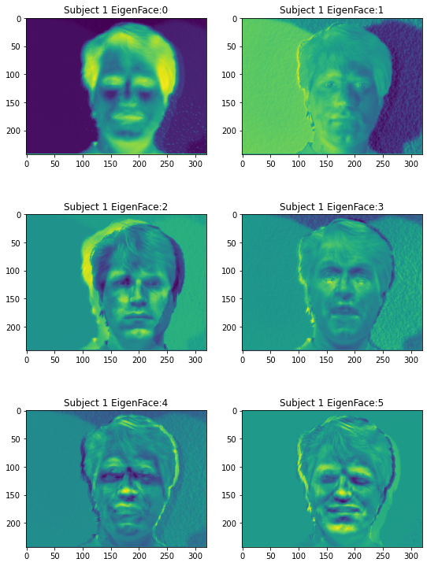

```python
w = 10
h = 10
fig = plt.figure(figsize=(9, 13))
columns = 2
rows = 3
ax = []
for i in range(columns*rows):
    img = subject_1_pc[i]
    ax.append( fig.add_subplot(rows, columns, i+1))
    ax[-1].set_title("Subject 1 EigenFace:"+str(i))
    plt.imshow(img)
plt.show()
```

As we can see from the output above, subject 1's "eigenfaces" certainly show some interesting behavior. In eigenface 0 we can see that PCA took strong cues from the subject's hair, eyes, chin, and mouth. In the second eigenface for subject 1, we can see what appears to be a shadow to the right side of the subject with the left illuminated. This is an especially interesting result given that the input dataset contained 2 images with lighting coming from either side. This eigenface could very well be PCA's accusation for such a difference in features. The remaining eigenfaces of subject one has much less clear features identifiable, which can be seen from the low contrast and color intensity of the images. However, in each of them we do see small highlights of facial features like the nose in eigenface 4, the cheekbones in eigenface 3, or chin and eyebrows of eigenface 5. Collectively I was very impressed with PCA's ability to derive some sort of features to the images. However, I still have my doubts as to whether they will prove useful in facial recognition tasks.

We can do the same for subject two as well:

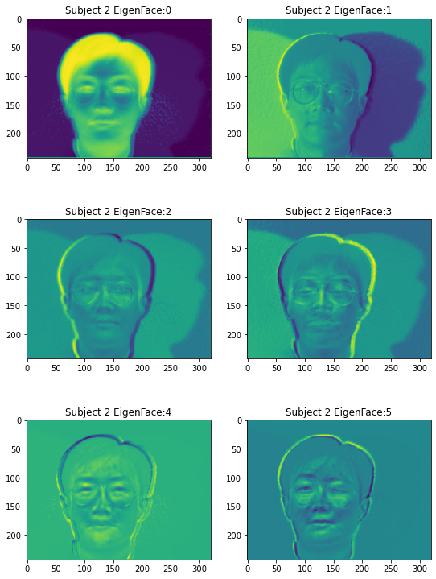

```python
w = 10
h = 10
fig = plt.figure(figsize=(9, 13))
columns = 2
rows = 3
ax = []
for i in range(columns*rows):
    img = subject_2_pc[i]
    ax.append( fig.add_subplot(rows, columns, i+1))
    ax[-1].set_title("Subject 2 EigenFace:"+str(i))
    plt.imshow(img)
plt.show()
```

In evaluating the eigenfaces generated form the training images of subject 2, it is notable to point out that we had a smaller dataset than subject 1 by a single image. As we can see from the eigenface 0 of subject 2, there is a striking contrasted generated between the figure and their surroundings. This behavior is very similar to that noted within the analysis of eigenface 0 of subject 1. As was the case with subject 1, eigenface 0 in subject 2 seems to place higher weights on the hair and eye features of the individual. It is notable however that subject 2 did not receive the highlighting of the chin area as subject 1 did. Again, when moving onto subject 2's eigenface 1, we see a distinct shadow pattern. This shadow pattern seems to persist in subject 2 more than subject 1. Collectively, we reach many of the same conclusions about subject 2 as we did with subject one which could spell trouble for a task that requires classification between two differing faces, but the algorithm was also not applied for such as task in this implementation to begin with. A closing note on this is also to note the immense importance eigenface 0 will always have over all subsequent eigenfaces as this is the projection that by far maximizes variance the most this can be demonstrated through basic examination of a sorted eigenvector plot.

$$s_{ij} =\frac{\textsf{(eigenface})_i^T \textsf{(test image)}_j}{\|\textsf{(eigenface}_i)\| \cdot\|\textsf{(test image)}_j\|}$$

```python
subject_1_eigen = []
subject_2_eigen = []
for i in subject_1_pc:
    subject_1_eigen.append(np.reshape(i,(77760)))
for j in subject_2_pc:
    subject_2_eigen.append(np.reshape(j,(77760)))

sub_1_eig_face_array = np.array(subject_1_eigen)
sub_2_eig_face_array = np.array(subject_2_eigen)

subject_1_best_face = np.expand_dims(subject_1_eigen[0],axis=1)
subject_2_best_face = np.expand_dims(subject_2_eigen[0],axis=1)
subject_1_test_array1 = subject_1_test_array.T
subject_2_test_array1 = subject_2_test_array.T


sub_1_dot = np.dot(subject_1_best_face.T,subject_1_test_array1)[0]
sub_1_dot2 = np.dot(subject_2_best_face.T,subject_1_test_array1)[0]

sub_2_dot = np.dot(subject_1_best_face.T,subject_2_test_array1)[0]
sub_2_dot2 = np.dot(subject_2_best_face.T,subject_2_test_array1)[0]

sub_1_normed_eig = np.linalg.norm(subject_1_best_face)
sub_2_normed_eig = np.linalg.norm(subject_2_best_face)

sub_1_test_norm = np.linalg.norm(subject_1_test_array1)
sub_2_test_norm = np.linalg.norm(subject_2_test_array1)


sub_1_norm_prod = np.multiply(sub_1_normed_eig,sub_1_test_norm)
sub_1_norm_prod2 = np.multiply(sub_2_normed_eig,sub_1_test_norm)

sub_2_norm_prod = np.multiply(sub_1_normed_eig,sub_2_test_norm)
sub_2_norm_prod2 = np.multiply(sub_2_normed_eig,sub_2_test_norm)



sub_1_score = sub_1_dot /sub_1_norm_prod
sub_1_score2 = sub_1_dot2 /sub_1_norm_prod2
sub_2_score = sub_2_dot /sub_2_norm_prod
sub_2_score2 = sub_2_dot2 /sub_2_norm_prod2

score_list = []
score_list.append(sub_1_score)
score_list.append(sub_2_score)
score_list.append(sub_1_score2)
score_list.append(sub_2_score2)

score_array = np.reshape(np.array(score_list),(2,2))
print(score_array)
```

```
[[-0.37465563 -0.0930631 ]
 [-0.12143056 -0.38930549]]
```